# 월수입과 보험가입 사이의 회귀분석

201803430 조성현

6/11/2021

##### 문제)

다음은 월수입과 보험 가입금액과의 관계를 알아보기 위해 조사에서 얻은 데이터의 일부이다. R을 이용하여 다음에 답하시오.

(단위 : 월 수입-만원, 보험가입금액-천만원)

| 월 수입 (만원) | 160 | 55 | 80 | 60 | 85 | 77 | 100 | 63 | 45 | 50 | 72 | 60 | 150 |
| --- | --- | --- | --- | --- | --- | --- | --- | --- | --- | --- | --- | --- | --- |
| 보험가입금액 (천만원) | 20 | 3.5 | 3.5 | 5 | 10 | 6.5 | 3 | 2.5 | 1.5 | 2 | 2 | 2.5 | 15 |

```
##     mi    ia
## 1  160 20000
## 2   55  3500
## 3   80  3500
## 4   60  5000
## 5   85 10000
## 6   77  6500
## 7  100  3000
## 8   63  2500
## 9   45  1500
## 10  50  2000
## 11  72  2000
## 12  60  2500
## 13 150 15000
```

##### 1.

산점도를 그리고, 표본상관계수를 추정하고 상관관계가 존재하는지 유의수준 1% 하에서 검정하시오.

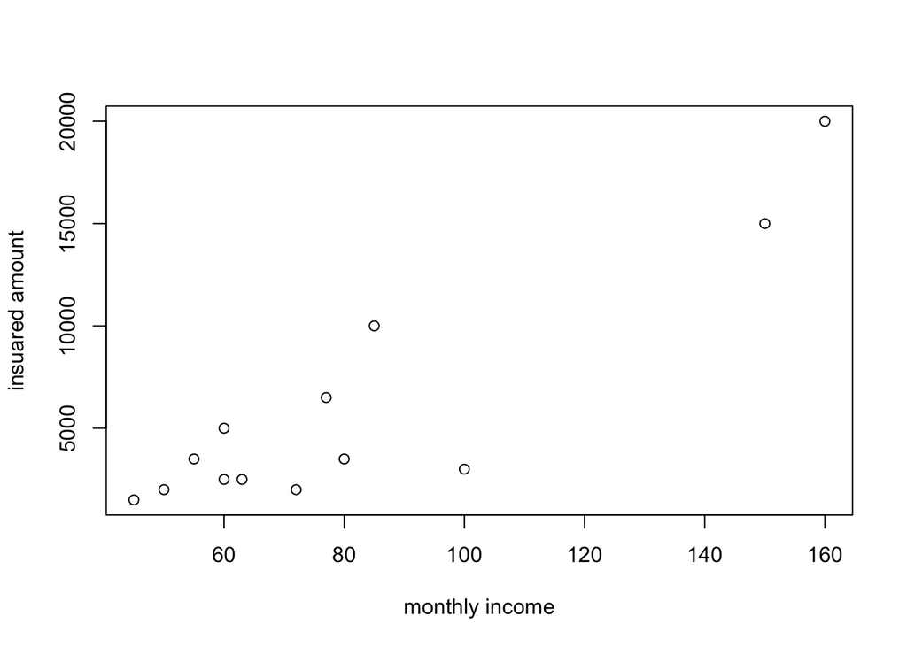

귀무 가설(H0): 월 수입과 보험 가입 금액 간의 상관 관계가 없다.

```
## [1] 0.9013935
```

```
##
##  Pearson's product-moment correlation
##
## data:  mi and ia
## t = 6.9043, df = 11, p-value = 2.573e-05
## alternative hypothesis: true correlation is not equal to 0
## 95 percent confidence interval:
##  0.6961584 0.9704168
## sample estimates:
##       cor
## 0.9013935
```

통계 결과)

통계량 t =6.904

추정된 상관계수는 r= 0.901 이다.

유의 확률(p-value): 2.573e-05 은,유의 수준 1 % = 0.01 보다 작다,

그렇므로 귀무 가설을 기각한다.

따라서 월 수입과 보험 가입 금액간 양의 상관관계가 있다 라고 할 수 있다.

##### 2.

분산분석표를 작성하고 추정된 회귀직선이 유의한지 유의수준 5% 하에서 검정하시오

귀무 가설 : 회귀 추정식이 유의 하지 않으며, 추정된 자료에서 멀다.

2-1.분산분석표

```
##             Df    Sum Sq   Mean Sq F value   Pr(>F)
## mi           1 318847749 318847749   47.67 2.57e-05 ***
## Residuals   11  73575328   6688666
## ---
## Signif. codes:  0 '***' 0.001 '**' 0.01 '*' 0.05 '.' 0.1 ' ' 1
```

통계 결과)

유의확률이 Pr(>F) :2.57e-05 이므로 유의수준 5%인 0.05 보다 작다

2-2.회귀 직선 추정

```
##
## Call:
## lm(formula = form, data = money)
##
## Residuals:
##     Min      1Q  Median      3Q     Max
## -5594.2  -807.0   550.7  1336.2  3549.3
##
## Coefficients:
##             Estimate Std. Error t value Pr(>|t|)
## (Intercept)  -5695.6     1829.3  -3.114  0.00986 **
## mi             142.9       20.7   6.904 2.57e-05 ***
## ---
## Signif. codes:  0 '***' 0.001 '**' 0.01 '*' 0.05 '.' 0.1 ' ' 1
##
## Residual standard error: 2586 on 11 degrees of freedom
## Multiple R-squared:  0.8125, Adjusted R-squared:  0.7955
## F-statistic: 47.67 on 1 and 11 DF,  p-value: 2.573e-05
```

통계결과)

유의확률이 p-value:2.57e-05 이므로 유의수준 5%인 0.05 보다 작다

그렇므로 귀무 가설을 기각한다.

결론

따라서 회귀 추정식이 유의하며, 추정된 자료에 멀지 않다 라고 할 수있다.

##### 3.

결정계수를 구하고 그 의미를 설명하시오.

결정 계수 ( R squared/coefficient determination ):

0 ~ 1 사이의 값을 가지며 1에가까울 수록 회귀식에 의한 설명력이 졸다고 한다.

통계 결과 Adjusted R-squared: 0.796

##### 4.

회귀모형 추정식을 쓰고, 의미를 설명하시오.

추정식: y = -5695.6 + 142.9x (y=insured amount(보험가입금액 | 단위: 만원), x = monthly income(월 수입 | 단위 :만원))

월수입 x에따라서 회귀모형 추정식에 따라 보험 가입 금액 y를 유추 할 수있다. 이때 기울기는 양수 이므로 월급이 증가함에 따라 추정식의 결과인 보험가입 금액도 선형적으로 증가한다라고 추정할 수 가있다.

##### 5.

회귀모형에서 오차에 대한 가정을 쓰고, 자료가 회귀모형을 적용하기에 적절한지 설명하시오

가정)

오차= 잔차= 관측값-회귀식에서의 추정값

오차에 대한 가정으로 정규성 등분산성을 검정 한다.

```
##
##  Shapiro-Wilk normality test
##
## data:  mod1$residuals
## W = 0.95766, p-value = 0.7173
```

잔차의 정규성 검정, 샤피로 검정을 이용한다. 유의 수준은 5%로 검정한다.

귀무 가설: 잔차는 정규성을 따른다.

유의 확률 p-value = 0.72 > 0.05 이므로 귀무 가설을 기각하지 않는다.

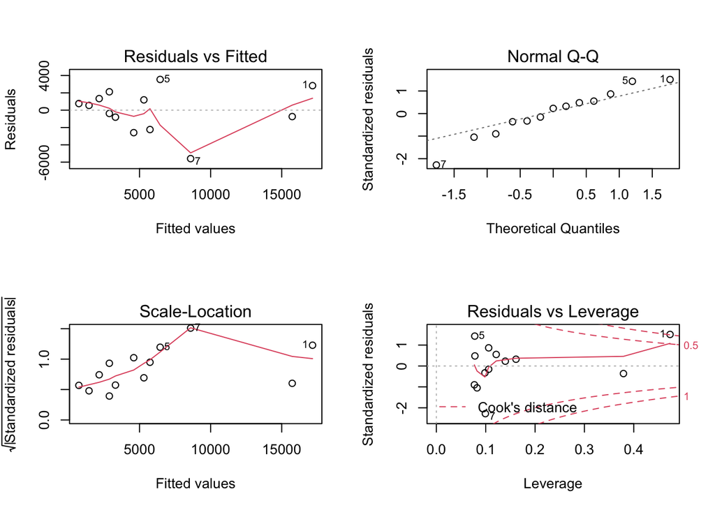

1번 그림좌측에 잔차가 선에따라모여 있는 것을 확인할 수있다.

2번 그림(Q-Q plot) 잔차의 정규성을 만족 하는것을 보여준다

3번 그림 (표준화 잔차) 기울기가 0인 직선이 이상적

4번 그림 왼쪽 가운데 몰려있어야 이상적

##### 6.

월 수입이 70만원일 때, 예상되는 보험가입금액을 구하시오.

```r
#월 수입 70 만원을 추정한 회귀식에 대입한다
x = 70
y= -5695.6 + 142.9*x
print(y)
```

```
## [1] 4307.4
```

월 수입이 70만원일 때,예상되는 보험 가입 금액 : 4307.4 (단위: 만원)